# Assignment 1

Rahmat Ashari

Feb 15, 2020

# Question 1

The grading in this class will be distributed across several evaluations: Clicker questions (10%), labs (10%), chapter quizzes (5%), two projects (10%), two midterm exams (20%), assignments (15%), and final exam (30%).Final grades will use standard grading with A for an overall grade of >90%, B >80%, and C for >70% and failing grades for <70%.

# Question 2

### a

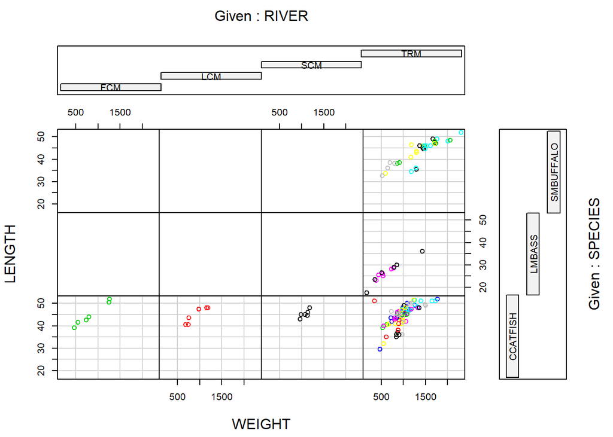

```r
data = read.csv('DDT.csv')

col_mile = factor(data[,'MILE'])

coplot(LENGTH~WEIGHT|RIVER*SPECIES,data = data, col = col_mile)
```

### b

The three lower left conditional plots suggest that:

1. CCATFISH were gathered at one specific mile at each river.
2. For CCATFISH found at FCM, LCM, and SCM rivers, the lenght seem to be affected by weight that can be modeled by linear model.

### c

Line #A `m=with(ddt, as.numeric(factor(MILE)))` categorizes the column ‘MILE’ from the ddt dataset (in this code I imported the dataset under the name ‘data’ not ‘ddt’) and store the data type as numeric.

### d

Line #B `length(unique(m))` returns the number of unique category in variable m, which is the categorized column ‘MILE’ from the ddt dataset.

### e

The top six plots are empty because the species LMBASS and SMBUFFALO were not found in the rivers FCM, LCM, and SCM.

### f

```r
subset1 = data[data$SPECIES == 'CCATFISH' & data$RIVER == 'FCM', 'DDT']
mean_q2 = mean(subset1)
cat('The mean value of DDT found in the sample species of CCATFISH and river of FCM is', mean_q2)
```

```
## The mean value of DDT found in the sample species of CCATFISH and river of FCM is 45
```

The mean value of DDT found in the sample species of CCATFISH and river of FCM is 45.

# Question 3

1. length of max span = quantitative
2. number of vehicle lanes = quantitative
3. toll bridge (T or F) = qualitative
4. average daily traffic = quantitative
5. condition of deck = qualitative
6. bypass or detour length = qunatitative
7. route type = qualitative

# Question 4

### a

4 names of random sampling designs:

1. simple random sample
2. stratified random sampling
3. cluster sampling
4. systematic sampling

### b

Brief description of random sampling designs:

1. **simple random sample**: sampling a number of experimental units in a way that the probability of each element to be picked is ensured to be the same.
2. **stratified random sampling**: sampling method where the experimental units are arranged into strata (groups that share similar characteristics) and a number of units then are picked from each strata and ultimately combined to form a representative set of samples.
3. **cluster sampling**: Experimental units are gathered from natural groupings (or clusters) to streamline the sampling process.
4. **systematic sampling**: This design systematically selects the *k*-th experimental unit from the list that consists all experimental units. This method is common in quality control practices.

# Question 5

```r
mtbe = read.csv('MTBE.csv')
head(mtbe)
```

```
##     pH SpConduct DissOxy RoadsPct IndPct UrbanPct DevPct WellClass Aquifier
## 1 7.87     290.0    0.58     1.34      0    17.77  17.77   Private  Bedrock
## 2 8.63     225.9    0.84     0.72      0    10.43  10.43   Private  Bedrock
## 3 7.11     157.4    8.37     1.92      0    29.62  50.01   Private  Bedrock
## 4 7.98     723.6    0.41     2.76      0    41.65  41.65   Private  Bedrock
## 5 7.88     148.7    1.44     3.51      0    51.21  51.21   Private  Bedrock
## 6 8.36     198.2    0.18     1.48      0    22.49  29.19   Private  Bedrock
##     Depth SafeYld Distance MTBE.Detect MTBE.Level HouseDen PopDen
## 1  60.960      NA  2386.29 Below Limit        0.2   131.16  43.19
## 2  36.576      NA  3667.69 Below Limit        0.2    47.69  24.52
## 3 152.400      NA  2324.15 Below Limit        0.2    85.16  33.32
## 4      NA      NA   788.88 Below Limit        0.2   134.77  46.61
## 5  91.440      NA  1337.88 Below Limit        0.2   198.54  78.58
## 6 115.824      NA  2396.74 Below Limit        0.2   206.73  59.47
```

```r
size_q5 = dim(mtbe)

#the code below takes 5 random numbers from a vector with size size[1] without replacement.
ind_q5 = sample(1:size_q5 [1], 5, replace = F)
#now to 'random sample' the mtbe df, just do simple indexing
mtbe[ind_q5,]
```

```
##       pH SpConduct DissOxy RoadsPct IndPct UrbanPct DevPct WellClass Aquifier
## 189 7.66    1019.0    0.43     2.44   7.22    60.58  62.01    Public  Bedrock
## 212 9.03     414.6    0.41     3.19   3.66    40.65  57.37    Public  Bedrock
## 56  5.58     865.2    2.86     1.97   0.56    17.49  25.99   Private  Bedrock
## 75  7.45     265.7    4.85     3.79   0.00    58.72  58.72   Private  Bedrock
## 6   8.36     198.2    0.18     1.48   0.00    22.49  29.19   Private  Bedrock
##        Depth  SafeYld Distance MTBE.Detect MTBE.Level HouseDen PopDen
## 189  80.1624 26.49508   916.83      Detect       0.96   332.67 163.41
## 212       NA       NA  3066.65 Below Limit       0.20   230.57  81.59
## 56   47.2440       NA   384.69 Below Limit       0.20    23.52   7.13
## 75  245.3640       NA   951.09 Below Limit       0.20    54.85  19.51
## 6   115.8240       NA  2396.74 Below Limit       0.20   206.73  59.47
```

### a-1)

Remove rows/observations containing at least one NA

```r
mtbeo = na.omit(mtbe)
head(mtbeo)
```

```
##       pH SpConduct DissOxy RoadsPct IndPct UrbanPct DevPct WellClass  Aquifier
## 104 7.43     663.2    0.56     2.26   0.00    27.42  27.42    Public Unconsoli
## 105 7.76     919.3    6.63    10.62  22.41    72.02  72.71    Public Unconsoli
## 106 7.01     409.9    5.94     1.58   0.84    20.88  20.88    Public Unconsoli
## 107 6.55     248.6    7.07     2.09   1.34    40.59  49.97    Public Unconsoli
## 108 7.91     223.0   10.60     4.10   6.54    43.08  43.08    Public Unconsoli
## 109 7.51     428.5    7.94     1.95   0.00    35.42  51.90    Public Unconsoli
##       Depth   SafeYld Distance MTBE.Detect MTBE.Level HouseDen PopDen
## 104 15.2400 1514.0045  1142.56      Detect       0.25    17.71   7.38
## 105 15.2400 1324.7540   274.61 Below Limit       0.20   132.22  46.20
## 106 19.2024 1052.2332   775.40 Below Limit       0.20    92.24  33.89
## 107 15.2400  946.2528   685.17 Below Limit       0.20   375.34 114.84
## 108 14.6304  946.2528  3192.79 Below Limit       0.20    77.01  34.23
## 109 24.9936  946.2528  2440.35      Detect       1.06   146.11  52.56
```

### a-2)

Compute the std dev of well depths that have ‘Bedrock’ as the aquifier *from the NA-omitted mtbe dataframe, which is mtbeo*

```r
depth = mtbeo[mtbeo$Aquifier == 'Bedrock', 'Depth']
sd_q5 = sd(depth)
cat('The std dev of well depths that have bedrock as aquifier is', sd_q5)
```

```
## The std dev of well depths that have bedrock as aquifier is 56.45357
```

# Question 6

```r
#Random sample of earthquake dataframe

eq = read.csv('EARTHQUAKE.csv')
size_q6 = dim(eq)
ind_q6 = sample(1:size_q6[1], 5, replace = F)
eq[ind_q6,]
```

```
##      ï..YEAR MONTH DAY HOUR MINUTE MAGNITUDE
## 2389    1994     2   1    1      3       1.6
## 960     1994     1  21   16     22       1.8
## 290     1994     1  18   15     12       2.3
## 2661    1994     2   3   15     28       1.8
## 824     1994     1  21    3     35       3.0
```

### a-1)

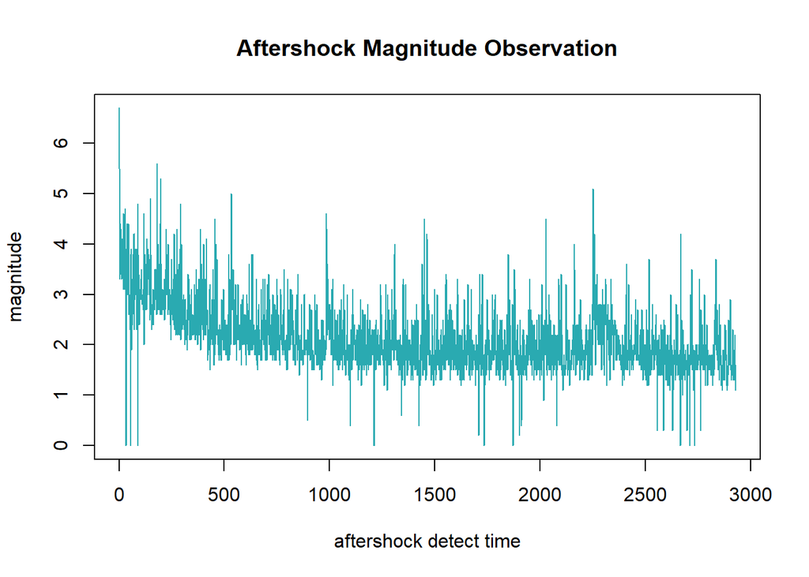

```r
mag_conv = ts(eq$MAGNITUDE) #ts() converts numeric to a time series
plot(mag_conv, xlab = 'aftershock detect time', ylab = 'magnitude', main = 'Aftershock Magnitude Observation', col = '#2AAAB1')
```

### a-2)

```r
median_q6 = median(eq$MAGNITUDE)
cat('The median for the aftershock magnitudes is',median_q6)
```

```
## The median for the aftershock magnitudes is 2
```

# Question 7

### a

The data collection method is a designed experiment, where fish specimen is gathered at various river and creek locations.

### b

The population is all the fish in the Tennessee River and its tributary creeks

### c

The **qualitative** variables in this study are RIVER and SPECIES.

# Question 8

### a

bar chart

### b

The variable measured is type of robotic limbs

### c

most used social robot design uses legs only

### d

```r
freq = c(15, 8, 63, 20)
rel_freq = freq/106
rnames = c('None', 'Both', 'Legs ONLY', 'Wheels ONLY')

data.frame(rel_freq, row.names = rnames)
```

```
##              rel_freq
## None        0.1415094
## Both        0.0754717
## Legs ONLY   0.5943396
## Wheels ONLY 0.1886792
```

### e

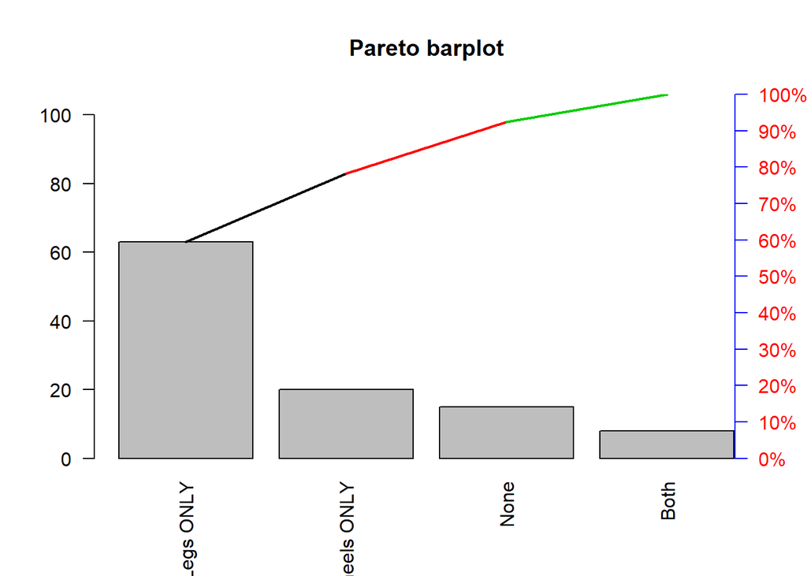

```r
pare_input = rep(rnames,freq)

pareto <- function(x,mn="Pareto barplot",...){  # x is a vector

  x.tab=table(x)
  xx.tab=sort(x.tab, decreasing=TRUE,index.return=FALSE)
  cumsum(as.vector(xx.tab))->cs
  length(x.tab)->lenx
  bp<-barplot(xx.tab,ylim=c(0,max(cs)),las=2)
  lb<-seq(0,cs[lenx],l=11)
  axis(side=4,at=lb,labels=paste(seq(0,100,length=11),"%",sep=""),las=1,line=-1,col="Blue",col.axis="Red")

  for(i in 1:(lenx-1)){
    segments(bp[i],cs[i],bp[i+1],cs[i+1],col=i,lwd=2)
  }
  title(main=mn,...)

}

pareto(pare_input)
```

# Question 9

### a

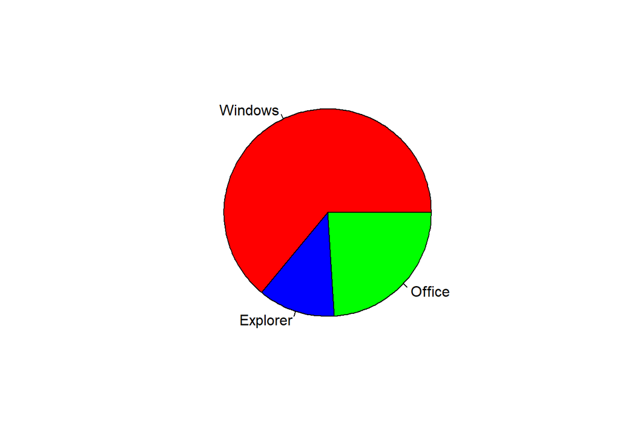

```r
categ = c('Windows', 'Explorer', 'Office')
categ_Issue = c(32, 6, 12)
pie(categ_Issue, labels = categ, col = c('red', 'blue', 'green'))
```

From pie chart, Explorer has lowest proportion of security issues.

### b

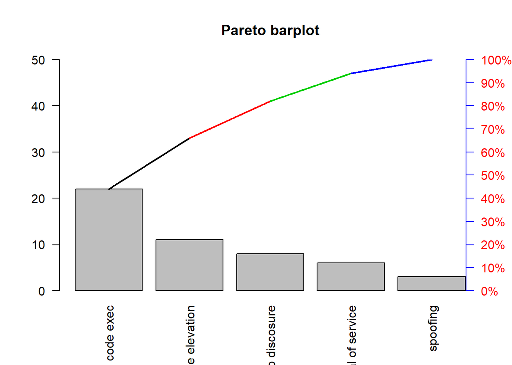

```r
reper = c('denial of service', 'info discosure','remote code exec', 'spoofing', 'privilege elevation')
reper_n = c(6,8,22,3,11)

pare_input2 = rep(reper, reper_n)
pareto(pare_input2)
```

Advise to focus on remote code execution.